# Multivariate_Model

Shiqi Zhang

2025-04-21

## Modeling Deer Intensity in BC with Elevation, Forest Cover, and Population Density

### Data preparation for multivariate models

```r
# Load packages
library(sp)
library(spatstat)
library(sf)
library(spatstat.geom)
```

```r
# Load the data
load("data/deer_data.Rdata")

# Load the window
win_bc_sf <- st_as_sf(deer_ppp$window)
win_bc <- as.owin(win_bc_sf)
```

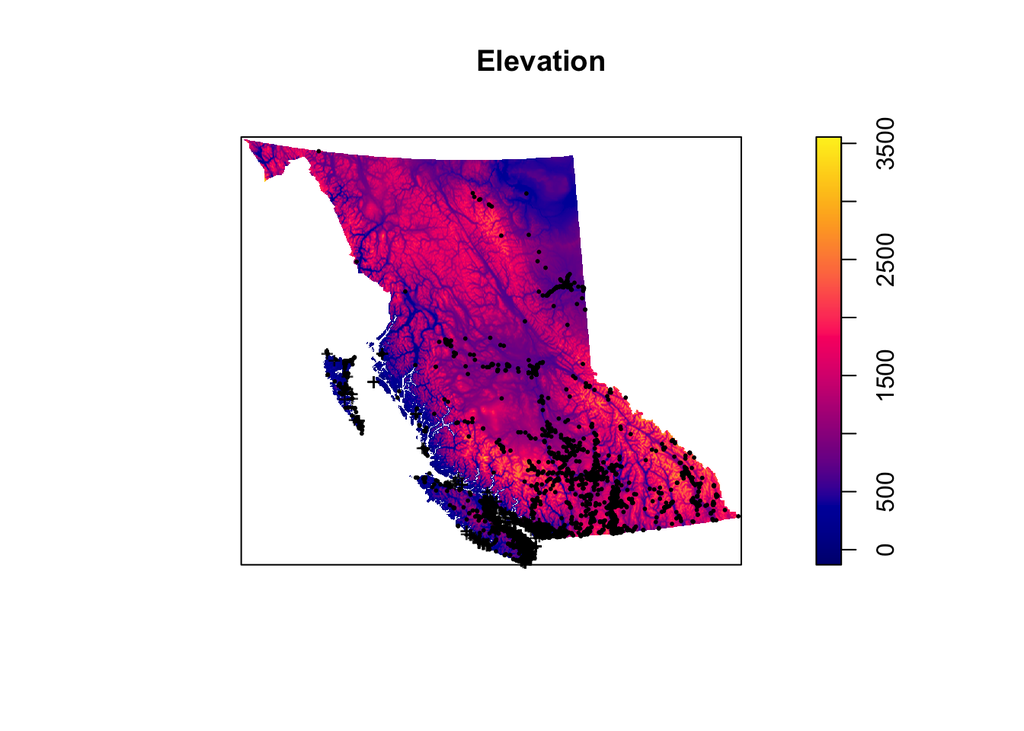

```r
# Plot the elevation with deer distribution
plot(elevation_im, main = "Elevation")
plot(deer_ppp,
     pch = 16,
     cex = 0.4,
     cols = "black",
     add = TRUE)
```

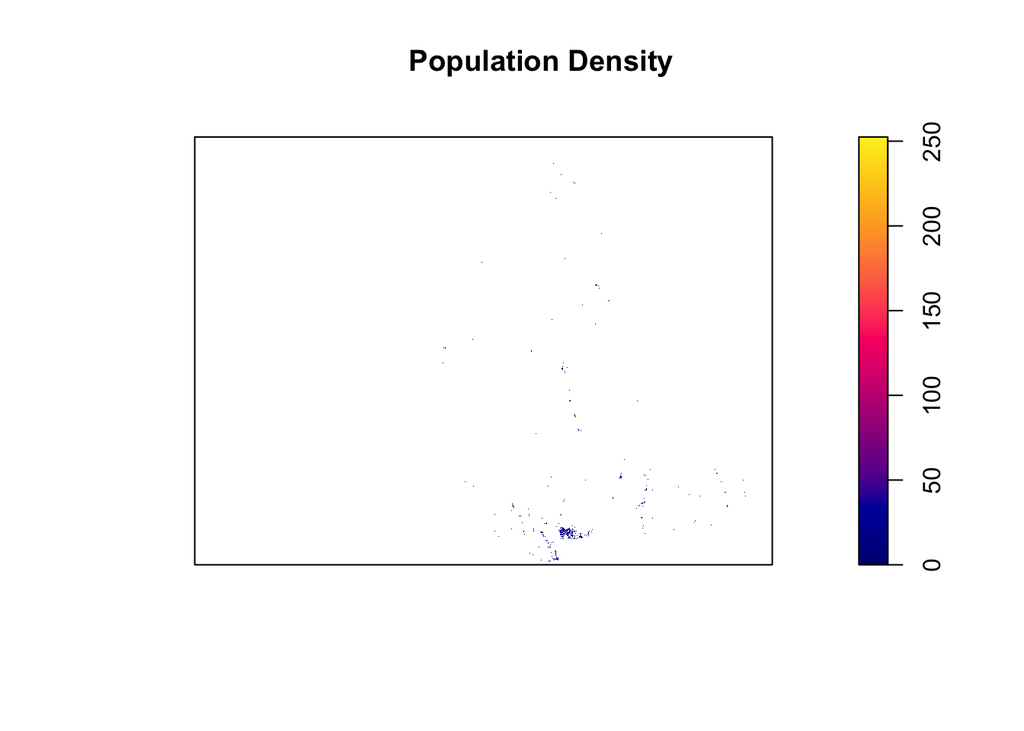

```r
# Plot the population
plot(pop_im, main = "Population Density")
```

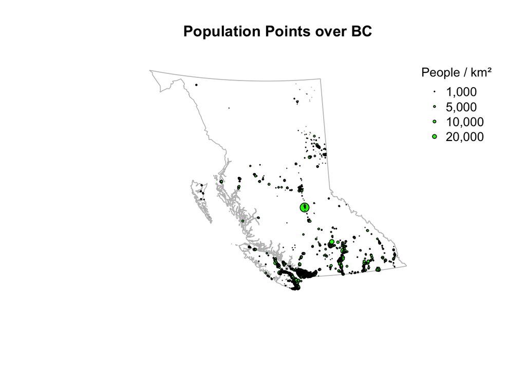

```r
# Replot without NA values
pop_km2 <- pop_im
pop_km2$v <- pop_km2$v * 100

# Convert pop_im (im) into point coordinates with values
pop_df <- as.data.frame(pop_km2)
pop_pts <- pop_df[!is.na(pop_df$value) & pop_df$value > 0, ]

# Scale dot size by population
pop_size <- sqrt(pop_pts$value) / 100

# Replot
plot(win_bc, main = "Population Points over BC", border = "grey")
points(pop_pts$x, pop_pts$y,
       pch = 21,
       bg = "green",
       col = "black",
       cex = pop_size)
legend("topright",
       legend = c("1,000", "5,000", "10,000", "20,000"),
       pt.cex = sqrt(c(1000, 5000, 10000, 20000)) / 200,
       pch = 21,
       pt.bg = "green",
       col = "black",
       title = "People / km²",
       bty = "n")
```

```r
# Apply kernel smoothing over the population raster using a Gaussian kernel with a ~2.5 km bandwidth
pop_smoothed <- Smooth(pop_im, sigma = 2500)

# Replace NA or zero/small values with a small positive floor
pop_smoothed$v[is.na(pop_smoothed$v) | pop_smoothed$v <= 0] <- 1e-6
```

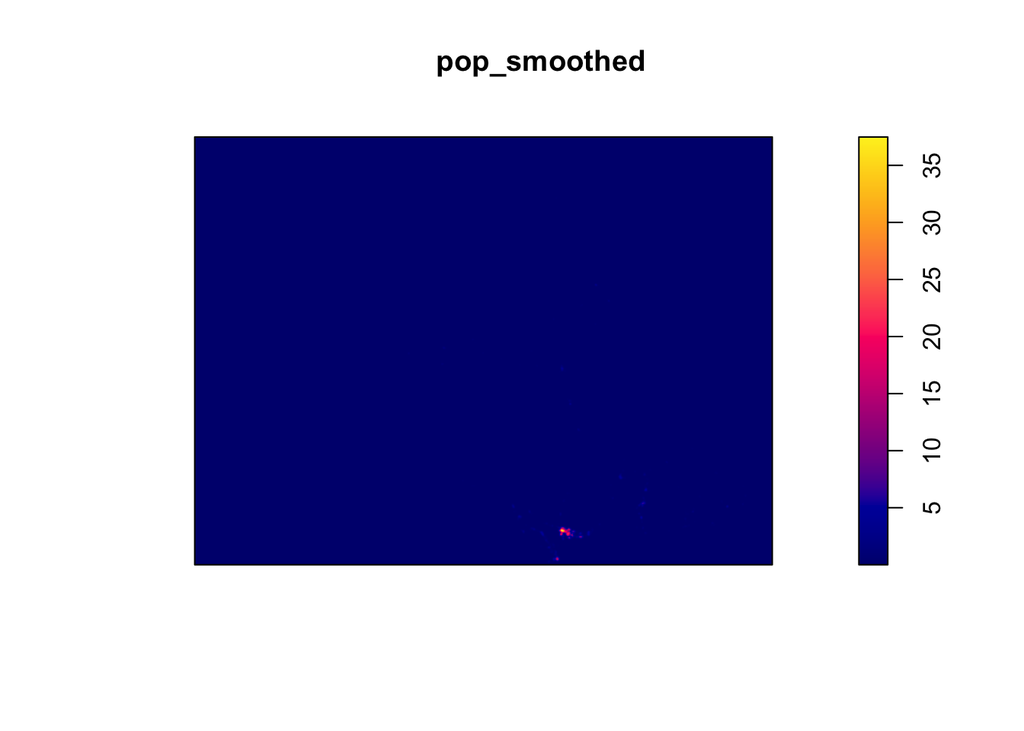

```r
plot(pop_smoothed)
```

```r
# Mask all covariates to BC window
forest_masked <- forest_im[win_bc, drop=FALSE]
elev_masked   <- elevation_im[win_bc, drop=FALSE]
pop_masked    <- pop_smoothed[win_bc, drop=FALSE]
```

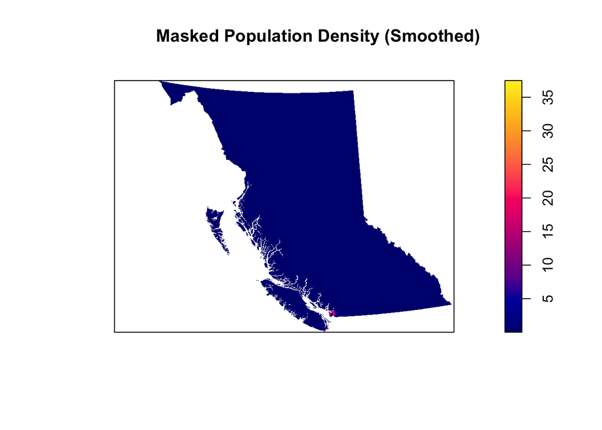

```r
# Visualize masked population
plot(pop_masked, main = "Masked Population Density (Smoothed)")
```

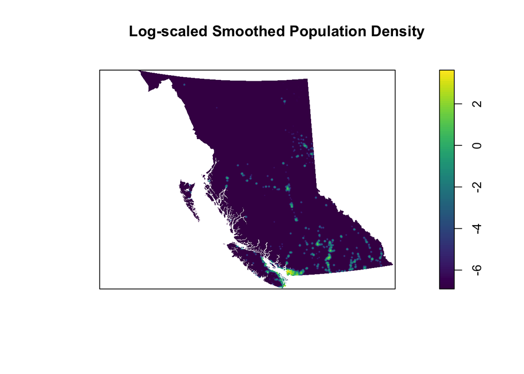

```r
# Add a small constant to avoid log(0)
pop_log <- eval.im(log(pop_masked + 1e-3))

#install.packages("viridis")
plot(pop_log,
     main = "Log-scaled Smoothed Population Density",
     col = viridis::viridis(100))
```

Now with the log-transformed, smoothed population density and the viridis color palette, the map clearly highlights populated corridors along the southern coast and interior valleys, while low-density regions become more distinguishable across the province.

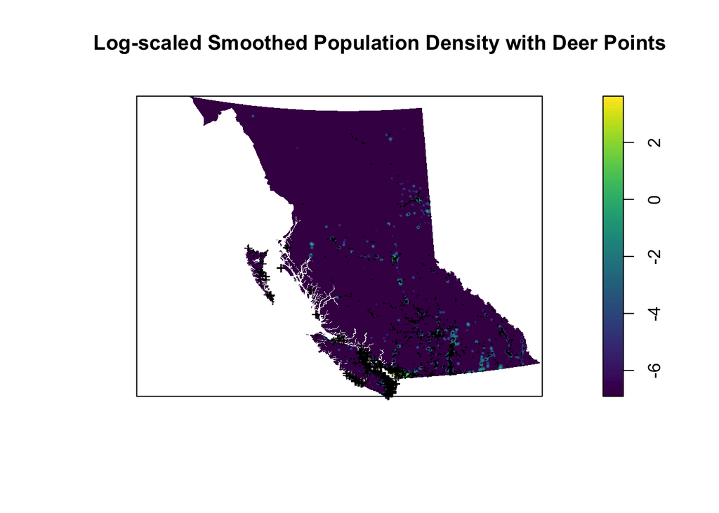

```r
# Overlay with the deer points
plot(pop_log,
     main = "Log-scaled Smoothed Population Density with Deer Points",
     col = viridis::viridis(100))
plot(deer_ppp,
     pch = 16,
     cex = 0.2,
     cols = "black",
     add = TRUE)
```

#### Check for collinearity

```r
# Create grid of elevation image coordinates
grid_xy <- expand.grid(x = elev_masked$xcol, y = elev_masked$yrow)

# Interpolate forest and pop at elevation grid locations
forest_at_elev <- interp.im(forest_masked, x = grid_xy$x, y = grid_xy$y)
pop_at_elev    <- interp.im(pop_masked, x = grid_xy$x, y = grid_xy$y)

# Get elevation values as flat vector
elev_vals <- as.vector(as.matrix(elev_masked))

# Combine into a clean data frame and remove NAs
cov_df <- data.frame(
  forest = forest_at_elev,
  elev   = elev_vals,
  pop    = pop_at_elev
)

cov_df <- na.omit(cov_df)
```

```r
# Compute correlation matrix and create visualization
cor(cov_df)
```

```
##             forest         elev          pop
## forest  1.00000000 -0.065133427 -0.027071201
## elev   -0.06513343  1.000000000 -0.001348614
## pop    -0.02707120 -0.001348614  1.000000000
```

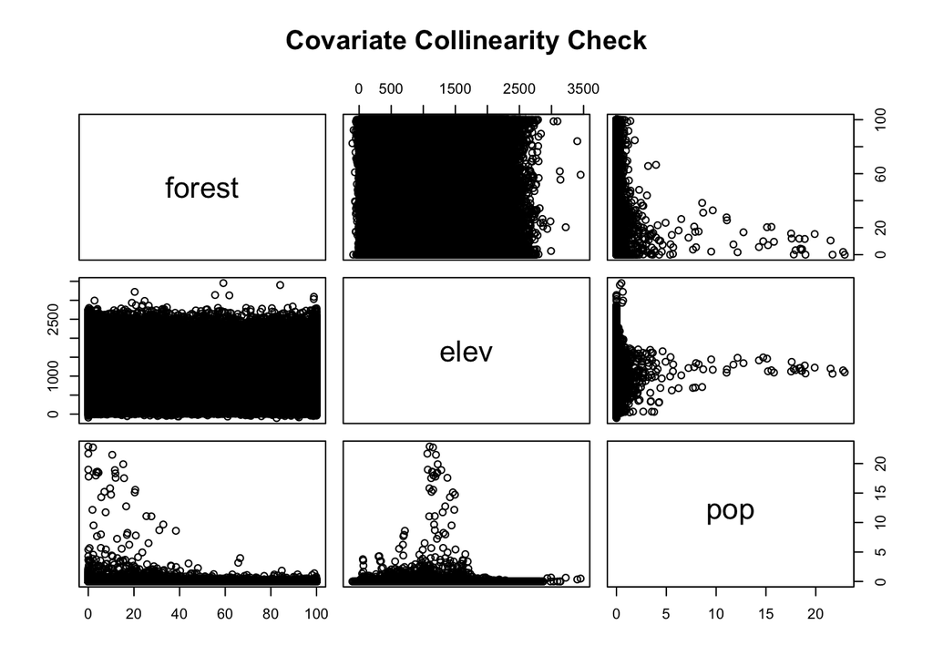

```r
pairs(cov_df, main = "Covariate Collinearity Check")
```

We checked for collinearity among forest cover, elevation, and population density by extracting aligned values across the study area and computing pairwise correlations. All correlation coefficients were close to zero, indicating minimal collinearity. Therefore, all three covariates were retained in the multivariate model.

#### Standardize the covariates and mask the response

```r
# Standardize the covariates
elev_std <- eval.im((elev_masked - mean(elev_masked, na.rm = TRUE)) / sd(elev_masked, na.rm = TRUE))
pop_std  <- eval.im((pop_masked - mean(pop_masked, na.rm = TRUE)) / sd(pop_masked, na.rm = TRUE))

# Create final mask for valid pixels across all covariates
valid_mask <- !is.na(forest_masked) & !is.na(elev_std) & !is.na(pop_std)

# Mask the deer point pattern
deer_valid <- deer_ppp[valid_mask]
```

### Fit the Polynomial Model

#### Multivariate point process model with a 3th-degree polynomial for forest cover, and quadratic terms for elevation and population density

```r
model_poly3cov <- ppm(deer_valid ~ polynom(forest, 3) + polynom(elev, 2) + polynom(pop, 2),
                      covariates = list(forest = forest_masked,
                                        elev = elev_std,
                                        pop = pop_std))
summary(model_poly3cov)
```

[output not shown]

[output cut: 803 more lines]

```
## ----------- gory details -----
##
## Fitted regular parameters (theta):
##   (Intercept)        forest   I(forest^2)   I(forest^3)          elev
## -1.922474e+01 -4.125101e-02  7.369678e-04 -5.207100e-06 -1.166748e+00
##     I(elev^2)           pop      I(pop^2)
##  2.210317e-01  4.658331e-01 -1.316239e-02
##
## Fitted exp(theta):
##  (Intercept)       forest  I(forest^2)  I(forest^3)         elev    I(elev^2)
## 4.475098e-09 9.595882e-01 1.000737e+00 9.999948e-01 3.113778e-01 1.247363e+00
##          pop     I(pop^2)
## 1.593341e+00 9.869239e-01
## Problem:
##  Values of the covariates 'forest', 'elev' were NA or undefined at 0.08% (24 out of 30177) of the quadrature points
```

#### Model Validation

```r
# AIC value
AIC(model_poly3cov)
```

```
## [1] 353449.9
```

```r
#Run the quadrat test
quadrat.test(model_poly3cov, nx = 5, ny = 4)
```

```
##
##  Chi-squared test of fitted Poisson model 'model_poly3cov' using quadrat
##  counts
##
## data:  data from model_poly3cov
## X2 = 7762, df = 8, p-value < 2.2e-16
## alternative hypothesis: two.sided
##
## Quadrats: 16 tiles (irregular windows)
```

The results mean there’s still significant spatial structure left unexplained.

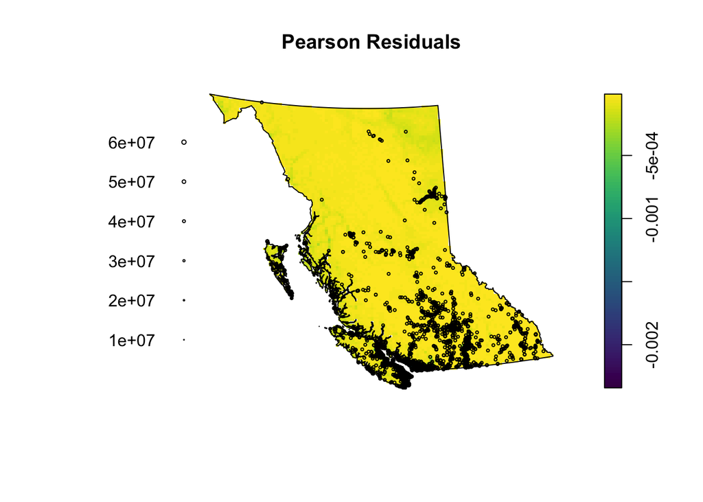

```r
# Residual analysis
# Calculate residuals
res_im <- residuals(model_poly3cov, type = "pearson", drop = TRUE)

# Plot residuals
library(viridis)
plot(res_im,
     main = "Pearson Residuals",
     col = viridis(100),
     ribbon = TRUE)
```

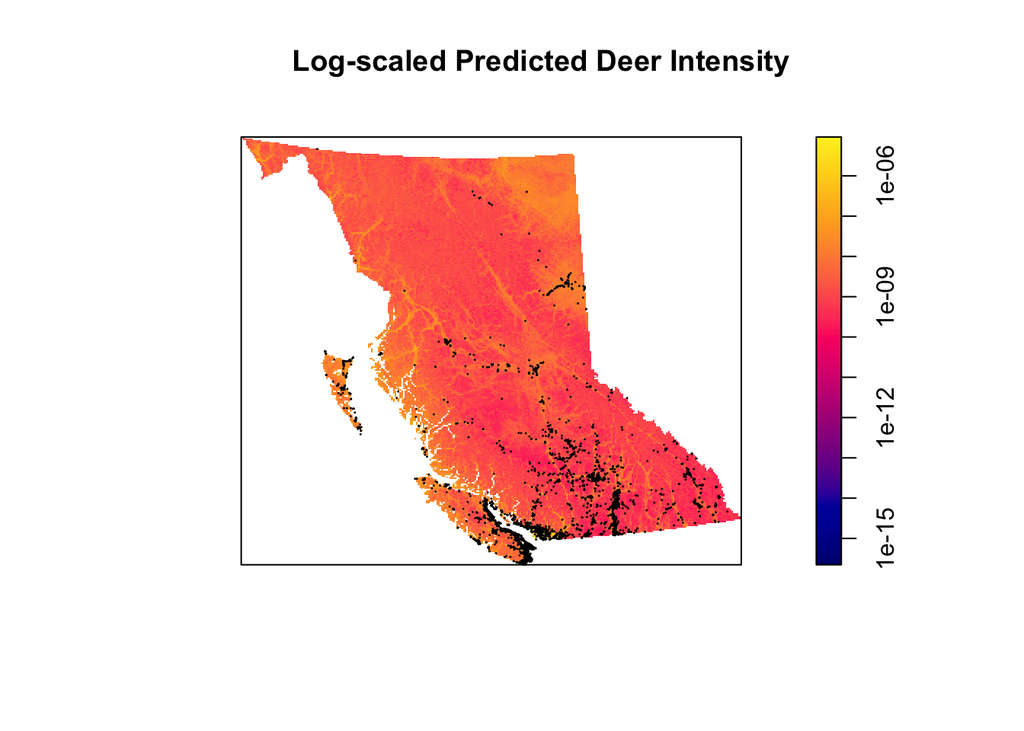

```r
# Log-scale intensity surface
plot(model_poly3cov,
log = TRUE,
se = FALSE,
superimpose = FALSE,
n = 300,
main = "Log-scaled Predicted Deer Intensity")

# Overlay observed park locations
plot(deer_valid,
pch = 16,
cex = 0.2,
cols = "black",
add = TRUE)
```

The Pearson residual plot shows that residuals are uniformly yellow across BC — that indicates it’s pretty good capturing the trends.

In the log-scaled predicted intensity map, the predicted values don’t match the observed deer well. The overall intensity is generally higher, but the gradient is more diffuse — it doesn’t distinguish dense areas from sparse ones very well. We see large regions with moderate predictions, even in places where deer presence is low.

### Fit the Polynomial Model with Log-transformed Population

```r
logpop <- eval.im(log(pop_masked + 1e-6))

model_poly_logpop <- ppm(deer_valid ~ polynom(forest, 3) + polynom(elev, 2) + polynom(pop, 2),
                      covariates = list(forest = forest_masked,
                                        elev = elev_std,
                                        pop = logpop))
summary(model_poly_logpop)
```

[output not shown]

[output cut: 803 more lines]

```
## ----------- gory details -----
##
## Fitted regular parameters (theta):
##   (Intercept)        forest   I(forest^2)   I(forest^3)          elev
## -1.560907e+01 -5.016129e-02  1.095362e-03 -6.977158e-06 -5.006466e-01
##     I(elev^2)           pop      I(pop^2)
##  2.024094e-01  4.702079e-01  9.168813e-03
##
## Fitted exp(theta):
##  (Intercept)       forest  I(forest^2)  I(forest^3)         elev    I(elev^2)
## 1.663673e-07 9.510760e-01 1.001096e+00 9.999930e-01 6.061386e-01 1.224349e+00
##          pop     I(pop^2)
## 1.600327e+00 1.009211e+00
## Problem:
##  Values of the covariates 'forest', 'elev' were NA or undefined at 0.08% (24 out of 30177) of the quadrature points
```

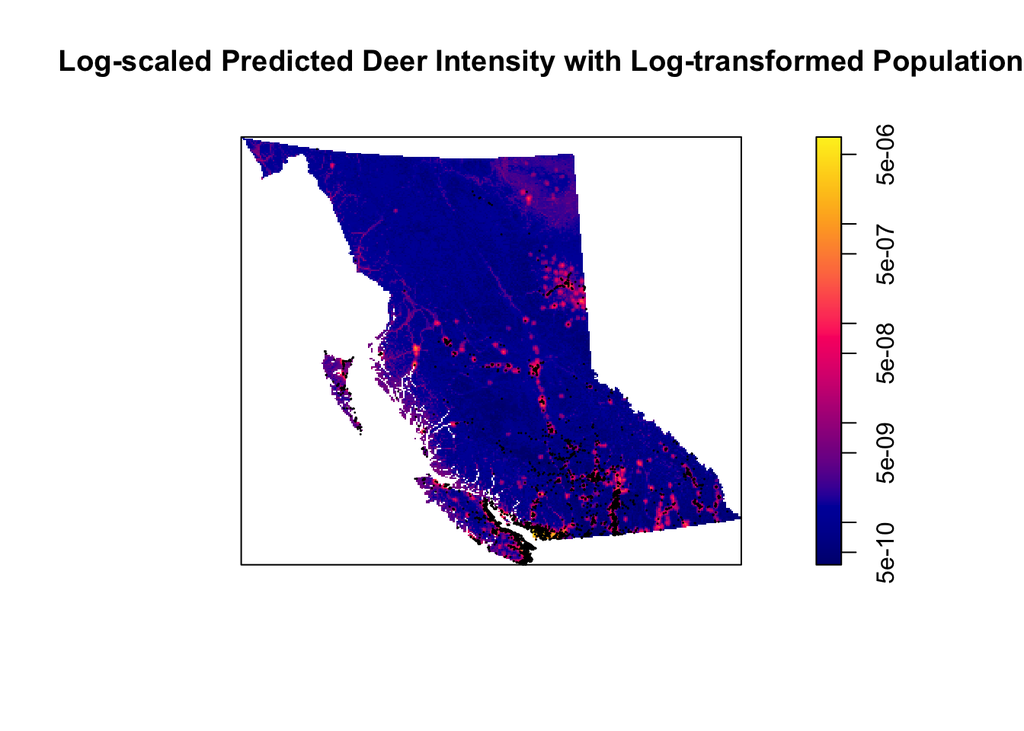

```r
# Log-scale intensity surface
plot(model_poly_logpop,
log = TRUE,
se = FALSE,
superimpose = FALSE,
n = 300,
main = "Log-scaled Predicted Deer Intensity with Log-transformed Population")

# Overlay observed park locations
plot(deer_valid,
pch = 16,
cex = 0.2,
cols = "black",
add = TRUE)
```

#### Model Validation

```r
# AIC value
AIC(model_poly_logpop)
```

```
## [1] 346672
```

AIC is lower compared to the previous model (~353,000+).

```r
#Run the quadrat test
quadrat.test(model_poly_logpop, nx = 5, ny = 4)
```

```
##
##  Chi-squared test of fitted Poisson model 'model_poly_logpop' using
##  quadrat counts
##
## data:  data from model_poly_logpop
## X2 = 2115.1, df = 8, p-value < 2.2e-16
## alternative hypothesis: two.sided
##
## Quadrats: 16 tiles (irregular windows)
```

Chi-squared value dropped dramatically (from ~7,700 to ~2,100).

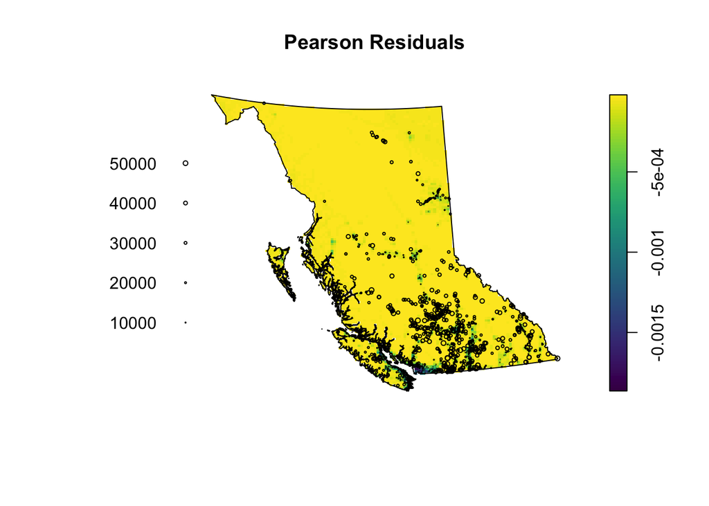

```r
# Residual analysis
# Calculate residuals
res <- residuals(model_poly_logpop, type = "pearson", drop = TRUE)

# Plot residuals
plot(res,
     main = "Pearson Residuals",
     col = viridis(100),
     ribbon = TRUE)
```

This version of the model with log-transformed population is a clear improvement:

The updated model incorporating log(pop) as a covariate significantly improves prediction quality. The log-scaled predicted intensity map now reveals a stronger spatial structure, with higher predicted deer intensity aligning better with known occurrence areas, particularly in southern BC and coastal regions. It sharpens the spatial contrast: areas with actual deer observations light up more clearly in orange, and low-density regions fade to deep blue. This cleaner separation better reflects the actual distribution of deer across BC.

The Pearson residuals are still very balanced and closer to zero overall, suggesting capturing the trends well. Additionally, the AIC decreased notably to 346,672, and the quadrat test chi-squared statistic dropped to 2,115.1, further indicating that the model captures more of the spatial variation in deer distribution compared to previous versions.

So statistically and visually, applying the log transformation on population dramatically improves spatial alignment and clarity of the predicted intensity.

### Assess Spatial Autocorrelation

```r
# Smooth residuals into an im object
res_im <- Smooth(res, sigma = 10000)

# Convert to data frame
res_df <- as.data.frame(res_im)
res_df <- na.omit(res_df)
```

#### Compute Moran’s I

```r
# Compute Moran’s I
#install.packages("ape")
#install.packages("fields")

library(ape)
library(fields)
coords <- cbind(res_df$x, res_df$y)
w <- 1 / (fields::rdist(coords) + 1e-6)  # avoid division by zero

moran_result <- Moran.I(res_df$value, w)
print(moran_result)
```

```
## $observed
## [1] 1
##
## $expected
## [1] -0.0001405679
##
## $sd
## [1] 0.01632594
##
## $p.value
## [1] 0
```

#### Compute Empirical Variogram

```r
#install.packages("gstat")
library(gstat)
```

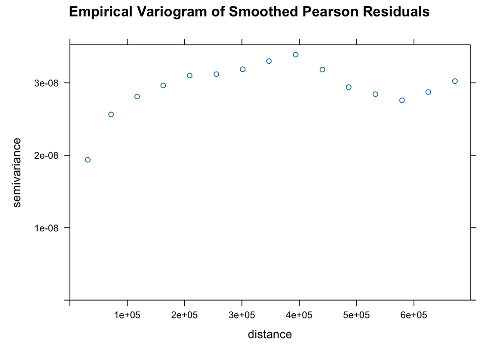

```r
library(sp)

# Prepare spatial points
spdf <- data.frame(residual = res_df$value, x = res_df$x, y = res_df$y)
coordinates(spdf) <- ~x + y

# Variogram
vg <- variogram(residual ~ 1, data = spdf)
plot(vg, main = "Empirical Variogram of Smoothed Pearson Residuals")
```

The residual analysis suggest that the model does not fully account for spatial dependence. Moran’s I on the smoothed Pearson residuals yielded a value of 1 with a p-value of 0, indicating strong and statistically significant positive spatial autocorrelation. This is further supported by the empirical variogram, which shows increasing semivariance with distance up to approximately 400,000 meters before flattening, suggesting spatial clustering in residuals. These findings imply that important spatial structure remains unexplained, motivating potential model refinement using more flexible spatial techniques such as generalized additive models (GAMs).

### Fit the GAM

```r
# Create grid of covariates
# Step 1: Get common pixel grid from forest_masked
grid_xy <- expand.grid(x = forest_masked$xcol, y = forest_masked$yrow)

# Step 2: Extract covariate values at the same locations
forest_vals <- interp.im(forest_masked, x = grid_xy$x, y = grid_xy$y)
elev_vals   <- interp.im(elev_std, x = grid_xy$x, y = grid_xy$y)
pop_vals    <- interp.im(logpop, x = grid_xy$x, y = grid_xy$y)
lambda_vals <- interp.im(predict(model_poly_logpop), x = grid_xy$x, y = grid_xy$y)

# Step 3: Combine into one data frame
gam_data <- data.frame(
  x = grid_xy$x,
  y = grid_xy$y,
  forest = forest_vals,
  elev = elev_vals,
  pop = pop_vals,
  log_lambda = lambda_vals
)

# Step 4: Remove any rows with NA
gam_data <- na.omit(gam_data)
```

```r
library(mgcv)
# Fit GAM with smooth terms
gam_model <- gam(log_lambda ~ s(forest) + s(elev) + s(pop), data = gam_data)

summary(gam_model)
```

```
##
## Family: gaussian
## Link function: identity
##
## Formula:
## log_lambda ~ s(forest) + s(elev) + s(pop)
##
## Parametric coefficients:
##              Estimate Std. Error t value Pr(>|t|)
## (Intercept) 7.535e-09  2.620e-11   287.6   <2e-16 ***
## ---
## Signif. codes:  0 '***' 0.001 '**' 0.01 '*' 0.05 '.' 0.1 ' ' 1
##
## Approximate significance of smooth terms:
##             edf Ref.df         F  p-value
## s(forest) 2.548  3.133     10.09 1.83e-06 ***
## s(elev)   8.729  8.979  14398.32  < 2e-16 ***
## s(pop)    8.996  9.000 594756.68  < 2e-16 ***
## ---
## Signif. codes:  0 '***' 0.001 '**' 0.01 '*' 0.05 '.' 0.1 ' ' 1
##
## R-sq.(adj) =  0.753   Deviance explained = 75.3%
## GCV = 1.5596e-15  Scale est. = 1.5595e-15  n = 2271978
```

```r
# Predict log intensity
gam_data$log_lambda_pred <- predict(gam_model, newdata = gam_data)
```

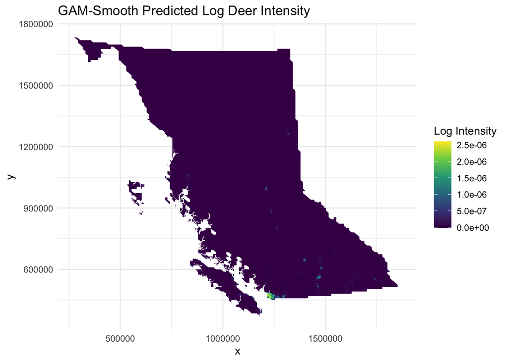

```r
library(ggplot2)

# GAM-smoothed log intensity map
ggplot(gam_data, aes(x = x, y = y, fill = log_lambda_pred)) +
  geom_tile() +
  coord_equal() +
  scale_fill_viridis_c(name = "Log Intensity") +
  labs(title = "GAM-Smooth Predicted Log Deer Intensity") +
  theme_minimal()
```

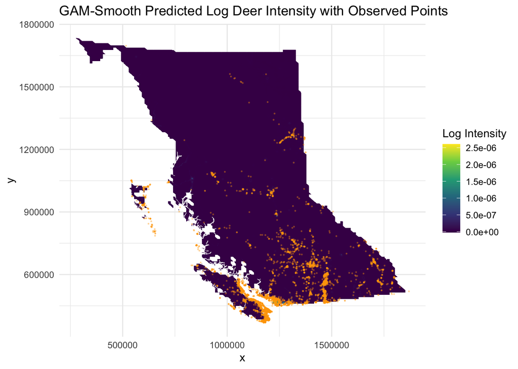

```r
# Overlay of the fitted GAM intensity map with deer occurrence points
deer_df <- as.data.frame(coords(deer_valid))
colnames(deer_df) <- c("x", "y")

ggplot(gam_data, aes(x = x, y = y, fill = log_lambda_pred)) +
  geom_tile() +
  geom_point(data = deer_df, aes(x = x, y = y),
             color = "orange", size = 0.2, alpha = 0.3, inherit.aes = FALSE) +
  coord_equal() +
  scale_fill_viridis_c(name = "Log Intensity") +
  labs(title = "GAM-Smooth Predicted Log Deer Intensity with Observed Points") +
  theme_minimal()
```

#### Model Validation

```r
# AIC value
AIC(gam_model)
```

```
## [1] -71014078
```

### Conclusion

In conclusion, we have successfully built a robust model to use forest cover, elevation, and human population to explain deer intensity. Starting from univariate Poisson point process models to obtain insights from different variables, we built up to a multivariate polynomial model and finally a Generalized Additive Model (GAM).

Through the bottom model building approach, we first gained insights of each individual covariates. Then, through Moran’s I and empirical variogram, we figured out there is residual spatial dependence. That’s why we decided to adopt a GAM for more flexibility.

In terms of model comparison, Although GAM captured complex nonlinear relationships and explained a substantial portion of the deviance, also achieved a much lower AIC, Poisson models built in the middle of the process remain valuable for their interpretability and theoretical grounding in spatial point process theory.